# Example Classification

```r
library(tidyverse)
```

```r
library(corrplot)
library(ggvis)
library(GGally)
library(ggExtra)
```

```r
#Load Data
song_table = read.csv('genre_music.csv',header = TRUE,sep = ",")

#change popularity to Hit or Flop
song_table$popularity_f = as.character(song_table$popularity)
song_table$popularity_f[song_table$popularity_f == 0] = "Flop"
song_table$popularity_f[song_table$popularity_f == 1] = "Hit"

#drop rows not wanted in classification
df_prep = subset(song_table, select = -c(track,artist,decade,duration_s,acousticness))

#factorize genre and popularity_f
df_prep$genre = as.factor(df_prep$genre)
df_prep$popularity_f = as.factor(df_prep$popularity_f)

#move popularity to end
df_prep = df_prep %>% relocate(popularity,.after = last_col())
```

##Classification Tree with Continuous Variables

```r
library(rpart)
```

```r
library(rpart.plot)
```

A 70/30 split was used for the test/train sets of the data.

```r
#Train Test split
set.seed(1)
sample = sample(c(TRUE, FALSE), nrow(df_prep), replace=TRUE, prob=c(0.7,0.3))
train = df_prep[sample, ]
test = df_prep[!sample, ]

#remove popularity
train_answer = subset(train, select = c(popularity))
train = subset(train, select = -c(popularity))

test_answer = subset(test,select = c(popularity))
test = subset(test,select = -c(popularity,popularity_f))
```

To see what the classification tree is using for variables, a small tree was created.

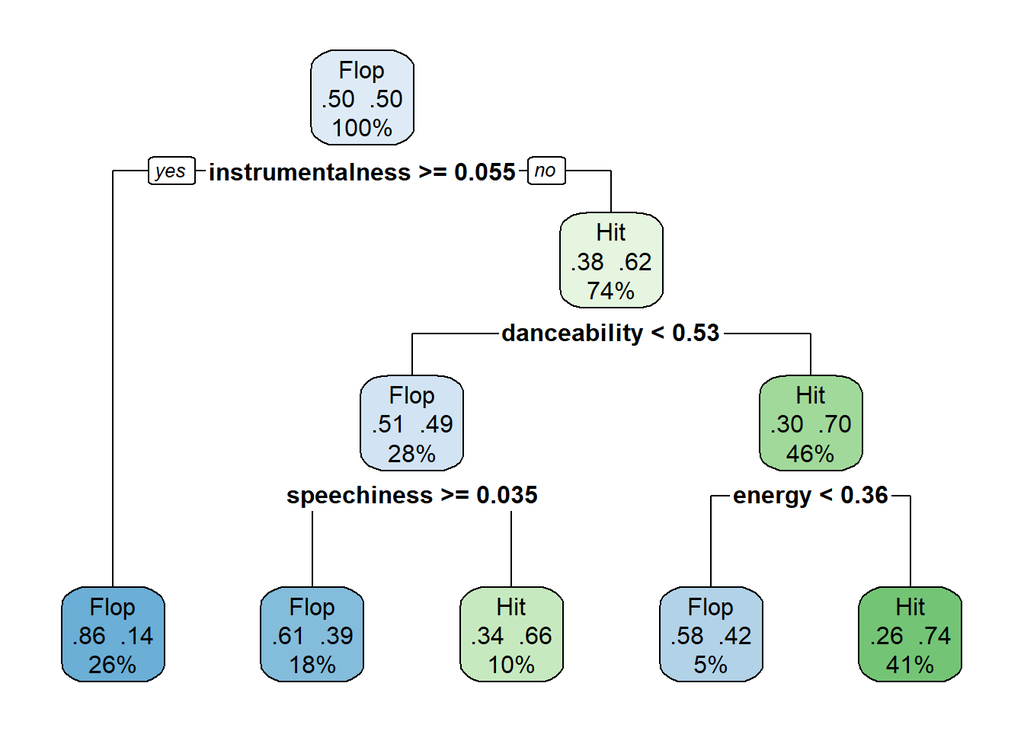

```r
control = rpart.control(minsplit = 2,
    maxdepth = 3,
    cp = 0)


dt.model = rpart(popularity_f~ .,
                    data = train, method = "class",control = control)

rpart.plot(dt.model,extra = 4+100)
```

The leaf nodes show the majority class, the probability of each class (impurity), and then the percent of the dataset at that node.

In this tree, the rightmost and leftmost leaf nodes are examples of good nodes where the probability of the correct class is high and a large portion of the data resides in that node.

Taking a look at the confusion matrix and model accuracy.

```r
#Train Prediction
train_prediction = predict(dt.model,train)
train_prediction = as.data.frame(train_prediction)

train_is_popular = train_prediction$Hit > 0.5
train_prediction$Popular = as.integer(as.logical(train_is_popular))

#Train Confusion matrix
train_table_mat = table(train_answer$popularity, train_prediction$Popular,
                        dnn = c("Actual","Predicted"))
train_table_mat
```

```
##       Predicted
## Actual     0     1
##      0 10335  4068
##      1  3745 10631
```

The split between False Positives and False Negatives is almost equal.

```r
#Train Accuracy
accuracy_train = sum(diag(train_table_mat))/sum(train_table_mat)
accuracy_train
```

```
## [1] 0.7285173
```

```r
#Test Prediction
test_prediction = predict(dt.model,test)
test_prediction = as.data.frame(test_prediction)

is_popular = test_prediction$Hit > 0.5
test_prediction$Popular = as.integer(as.logical(is_popular))

#Test Confusion matrix
test_table_mat = table(test_answer$popularity, test_prediction$Popular,
                       dnn = c("Actual","Predicted") )
test_table_mat
```

```
##       Predicted
## Actual    0    1
##      0 4328 1820
##      1 1592 4580
```

```r
#Test Accuracy
accuracy_test = sum(diag(test_table_mat))/sum(test_table_mat)
accuracy_test
```

```
## [1] 0.7230519
```

The Test/Validation accuracy is similar to the Model accuracty. We would expect in a real dataset that the accuracy of the model would be around 72%

#Classification with Discretized Data

```r
library(arules)
num_data = song_table[,sapply(song_table,is.numeric)]


num_data_disc = discretizeDF(num_data,default = list(method = "frequency"))
#factorize already discrete values
num_data_disc$key = as.factor(num_data$key)
num_data_disc$mode = as.factor(num_data$mode)
num_data_disc$time_signature = as.factor(num_data$time_signature)
num_data_disc$popularity = as.factor(num_data$popularity)
num_data_disc$genre = as.factor(song_table$genre)

str(num_data_disc)
```

```
## 'data.frame':    41099 obs. of  17 variables:
##  $ danceability    : Factor w/ 3 levels "[0,0.471)","[0.471,0.629)",..: 1 2 3 2 2 3 3 3 2 2 ...
##   ..- attr(*, "discretized:breaks")= num [1:4] 0 0.471 0.629 0.988
##   ..- attr(*, "discretized:method")= chr "frequency"
##  $ energy          : Factor w/ 3 levels "[0.000251,0.469)",..: 2 2 2 2 3 2 1 2 1 2 ...
##   ..- attr(*, "discretized:breaks")= num [1:4] 0.000251 0.469 0.723 1
##   ..- attr(*, "discretized:method")= chr "frequency"
##  $ key             : Factor w/ 12 levels "0","1","2","3",..: 4 4 6 8 12 1 1 6 3 3 ...
##  $ loudness        : Factor w/ 3 levels "[-49.3,-11.5)",..: 2 1 1 1 3 2 1 2 1 2 ...
##   ..- attr(*, "discretized:breaks")= num [1:4] -49.25 -11.51 -7.29 3.74
##   ..- attr(*, "discretized:method")= chr "frequency"
##  $ mode            : Factor w/ 2 levels "0","1": 2 2 2 1 1 2 2 1 1 2 ...
##  $ speechiness     : Factor w/ 3 levels "[0,0.0363)","[0.0363,0.0568)",..: 2 1 2 3 3 1 1 2 3 1 ...
##   ..- attr(*, "discretized:breaks")= num [1:4] 0 0.0363 0.0568 0.96
##   ..- attr(*, "discretized:method")= chr "frequency"
##  $ acousticness    : Factor w/ 3 levels "[0,0.0862)","[0.0862,0.535)",..: 2 1 3 3 3 3 2 3 3 1 ...
##   ..- attr(*, "discretized:breaks")= num [1:4] 0 0.0862 0.535 0.996
##   ..- attr(*, "discretized:method")= chr "frequency"
##  $ instrumentalness: Factor w/ 3 levels "[0,3.1e-06)",..: 1 3 2 3 2 3 3 1 3 1 ...
##   ..- attr(*, "discretized:breaks")= num [1:4] 0.00 3.10e-06 6.06e-03 1.00
##   ..- attr(*, "discretized:method")= chr "frequency"
##  $ liveness        : Factor w/ 3 levels "[0.013,0.105)",..: 1 2 2 1 3 2 1 3 3 2 ...
##   ..- attr(*, "discretized:breaks")= num [1:4] 0.013 0.105 0.199 0.999
##   ..- attr(*, "discretized:method")= chr "frequency"
##  $ valence         : Factor w/ 3 levels "[0,0.408)","[0.408,0.699)",..: 3 3 3 3 3 3 2 3 1 2 ...
##   ..- attr(*, "discretized:breaks")= num [1:4] 0 0.408 0.699 0.996
##   ..- attr(*, "discretized:method")= chr "frequency"
##  $ tempo           : Factor w/ 3 levels "[0,104)","[104,129)",..: 3 1 2 2 2 2 3 2 2 2 ...
##   ..- attr(*, "discretized:breaks")= num [1:4] 0 104 129 241
##   ..- attr(*, "discretized:method")= chr "frequency"
##  $ duration_s      : Factor w/ 3 levels "[15.2,189)","[189,247)",..: 1 2 2 1 2 1 1 1 1 1 ...
##   ..- attr(*, "discretized:breaks")= num [1:4] 15.2 189 247.5 4170.2
##   ..- attr(*, "discretized:method")= chr "frequency"
##  $ time_signature  : Factor w/ 5 levels "0","1","3","4",..: 3 4 4 4 4 4 4 4 4 4 ...
##  $ chorus_hit      : Factor w/ 3 levels "[0,30.2)","[30.2,42.9)",..: 2 3 2 1 1 3 3 2 3 3 ...
##   ..- attr(*, "discretized:breaks")= num [1:4] 0 30.2 42.9 433.2
##   ..- attr(*, "discretized:method")= chr "frequency"
##  $ sections        : Factor w/ 3 levels "[0,9)","[9,11)",..: 2 2 3 1 3 1 1 1 1 2 ...
##   ..- attr(*, "discretized:breaks")= num [1:4] 0 9 11 169
##   ..- attr(*, "discretized:method")= chr "frequency"
##  $ popularity      : Factor w/ 2 levels "0","1": 2 1 1 1 1 1 1 2 1 2 ...
##  $ genre           : Factor w/ 6 levels "edm","latin",..: 1 3 3 3 4 3 3 3 3 3 ...
```

```r
#change popularity to Hit or Flop
num_data_disc$popularity_f = as.character(num_data_disc$popularity)
num_data_disc$popularity_f[num_data_disc$popularity_f == 0] = "Flop"
num_data_disc$popularity_f[num_data_disc$popularity_f == 1] = "Hit"

#drop rows not wanted in classification
df_prep2 = subset(num_data_disc, select = -c(duration_s,acousticness))
```

```r
#Train Test split
set.seed(1)
sample = sample(c(TRUE, FALSE), nrow(df_prep2), replace=TRUE, prob=c(0.7,0.3))
train = df_prep2[sample, ]
test = df_prep2[!sample, ]

#remove popularity
train_answer = subset(train, select = c(popularity))
train = subset(train, select = -c(popularity))

test_answer = subset(test,select = c(popularity))
test = subset(test,select = -c(popularity,popularity_f))
```

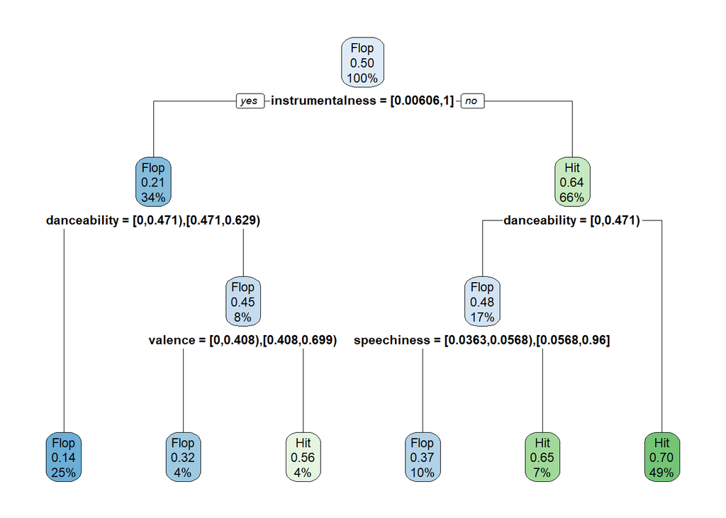

```r
control = rpart.control(minsplit = 2,
    maxdepth = 3,
    cp = 0)


dt.model = rpart(popularity_f~ .,
                    data = train, method = "class",control = control)

rpart.plot(dt.model)
```

The discretized classification tree is different than with continuous variables.

```r
#Train Prediction
train_prediction = predict(dt.model,train)
train_prediction = as.data.frame(train_prediction)

train_is_popular = train_prediction$Hit > 0.5
train_prediction$Popular = as.integer(as.logical(train_is_popular))

#Train Confusion matrix
train_table_mat = table(train_answer$popularity, train_prediction$Popular,
                        dnn = c("Actual","Predicted"))
train_table_mat
```

```
##       Predicted
## Actual     0     1
##      0  8921  5482
##      1  2461 11915
```

```r
#Train Accuracy
accuracy_train = sum(diag(train_table_mat))/sum(train_table_mat)
accuracy_train
```

```
## [1] 0.7240001
```

```r
#Test Prediction
test_prediction = predict(dt.model,test)
test_prediction = as.data.frame(test_prediction)

is_popular = test_prediction$Hit > 0.5
test_prediction$Popular = as.integer(as.logical(is_popular))

#Test Confusion matrix
test_table_mat = table(test_answer$popularity, test_prediction$Popular,
                       dnn = c("Actual","Predicted") )
test_table_mat
```

```
##       Predicted
## Actual    0    1
##      0 3727 2421
##      1 1055 5117
```

```r
#Test Accuracy
accuracy_test = sum(diag(test_table_mat))/sum(test_table_mat)
accuracy_test
```

```
## [1] 0.7178571
```

Even with those differences, the accuracy of the models are similar.